# Applied statistical testing for DM

Caragea Anda-Maria, Hoisan Stefan-Alexandru

08/01/2023

## 1. Distributiile de esantionare

**Distributia de esantionare** se refera la studierea mai multor esantioane aleatorii colectate de la o anumita populatie pe baza unui atribut specific. Rezultatele obtinute ofera o imagine clara a variatiilor probabilitatii rezultatelor obtinute. Ca urmare, analistii raman la curent cu rezultatele si, prin urmare, se pot pregati pentru a lua masuri in consecinta.

### 1.1 Distributia de esantionare a mediei

Statistica utilizata pentru estimarea mediei unei populatii, **μ**, este media esantionului, **x̄**. Dacă **x̄** are o distributie cu medie **μ**, abatere standard **σ** si este distribuit aproximativ normal sau **n** este mare, atunci este distribuit aproximativ normal cu medie **μ** si eroare standard **σ / √ n**.

- **Teorema limitei centrale**

Teorema limitei centrale (CLT) afirma ca distributia esantionului se apropie de o distributie normala (cunoscuta si sub numele de „curba clopot”) pe masura ce dimensiunea esantionului devine mai mare, presupunand ca toate esantioanele sunt identice ca dimensiune, si indiferent de forma distributiei populatiei. Altfel spus, CLT este o teorie statistica care afirma ca, avand in vedere o dimensiune suficient de mare a esantionului dintr-o populatie cu un nivel finit de varianta, media tuturor esantioanelor din aceeasi populatie va fi aproximativ egala cu media populatiei. In plus, toate esantioanele vor urma un model aproximativ normal de distributie, toate variatiile fiind aproximativ egale cu varianta populatiei, impartita la dimensiunea fiecarui esantion.

De exemplu, sa presupunem ca temperatura maxima zilnica din luna ianuarie in Dunedin, Noua Zeelanda, urmeaza o distributie normala, cu o medie de 22 de grade Celsius si o abatere standard de 1,5 grade. Pentru esantioanele de dimensiunea n = 5, distributia de esantionare a lui x va fi normala, cu media 22 si o eroare standard de 1,5/ √ 5 ≈ 0,671.

In acest exemplu, distributia de esantionare a lui x este o distributie normala mai inalta, mai mica. Se asteapta o variabilitate mai mica intr-o medie a mai multor masuratori spre deosebire de masuratorile brute, individuale. In plus, prezenta lui n in numitorul erorii standard dicteaza o distributie mai precisa in jurul mediei daca se mareste dimensiunea esantionului, ceea ce inseamna ca va „varia mai putin” intre esantioanele de dimensiuni mai mari.

```r
xvals <- seq(16,28,by=0.1)
fx.samp <- dnorm(xvals,22,1.5/sqrt(5))
plot(xvals,fx.samp,type="l",lty=2,lwd=2,xlab="",ylab="")
abline(h=0,col="gray")
fx <- dnorm(xvals,22,1.5)
lines(xvals,fx,lwd=2)
legend("topright",legend=c("raw obs. distbn.","sampling distbn. (mean)"),
lty=1:2,lwd=c(2,2),bty="n")

#probabilitatea ca o zi din luna ianuarie, aleasa aleatoriu, sa aiba o temperatura maxima de 21,5 grade:
pnorm(21.5,mean=22,sd=1.5)
```

```
## [1] 0.3694413
```

```r
#probabilitatea ca media esantionului sa fie mai mica de 21,5 grade, pe baza unui esantion cu 5 zile din ianuarie
pnorm(21.5,mean=22,sd=1.5/sqrt(5))
```

```
## [1] 0.2280283
```

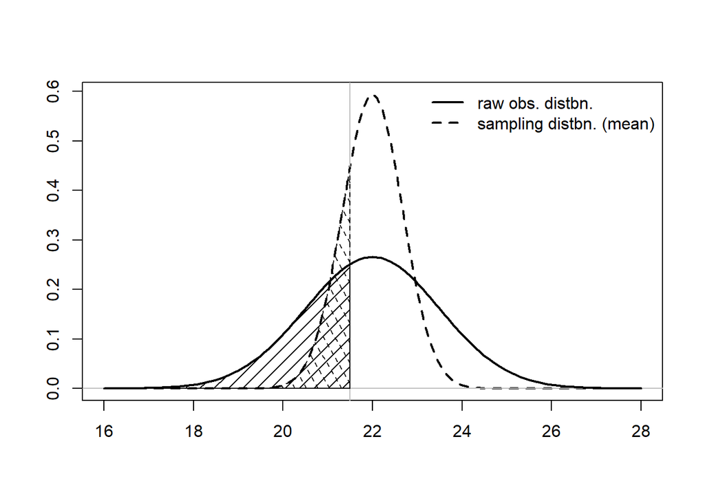

```r
#Zonele umbrite cu lunii arata aceste doua probabilitati.
abline(v=21.5,col="gray")
xvals.sub <- xvals[xvals<=21.5]
fx.sub <- fx[xvals<=21.5]
fx.samp.sub <- fx.samp[xvals<=21.5]
polygon(cbind(c(21.5,xvals.sub),c(0,fx.sub)),density=10)
polygon(cbind(c(21.5,xvals.sub),c(0,fx.samp.sub)),density=10,
angle=120,lty=2)
```

```r
#Generarea aleatorie a 5 temperaturi din Dunedin din distributia X ∼ N(22,1.5)
obs <- rnorm(5,mean=22,sd=1.5)
obs
```

```
## [1] 26.08336 22.63919 23.54762 18.94193 25.01329
```

```r
#presupunem ca cele 5 valori constituie toate datele pe care le avem:
obs.mean <- mean(obs)
obs.mean
```

```
## [1] 23.24508
```

```r
obs.sd <- sd(obs)
obs.sd
```

```
## [1] 2.745819
```

```r
#estimarea erorii standard se calculeaza astfel:
obs.mean.se <- obs.sd/sqrt(5)
obs.mean.se
```

```
## [1] 1.227968
```

```r
#gasirea probabilitatii ca media temperaturii e mai mica de 21,5 prin standardizarea valorii
t4 <- (21.5 - obs.mean)/obs.mean.se
t4
```

```
## [1] -1.421109
```

```r
#t4 urmeaza distributia t cu 4 grade de libertate. Probabilitatea estimata:

pt(t4,df=4)
```

```
## [1] 0.1141653
```

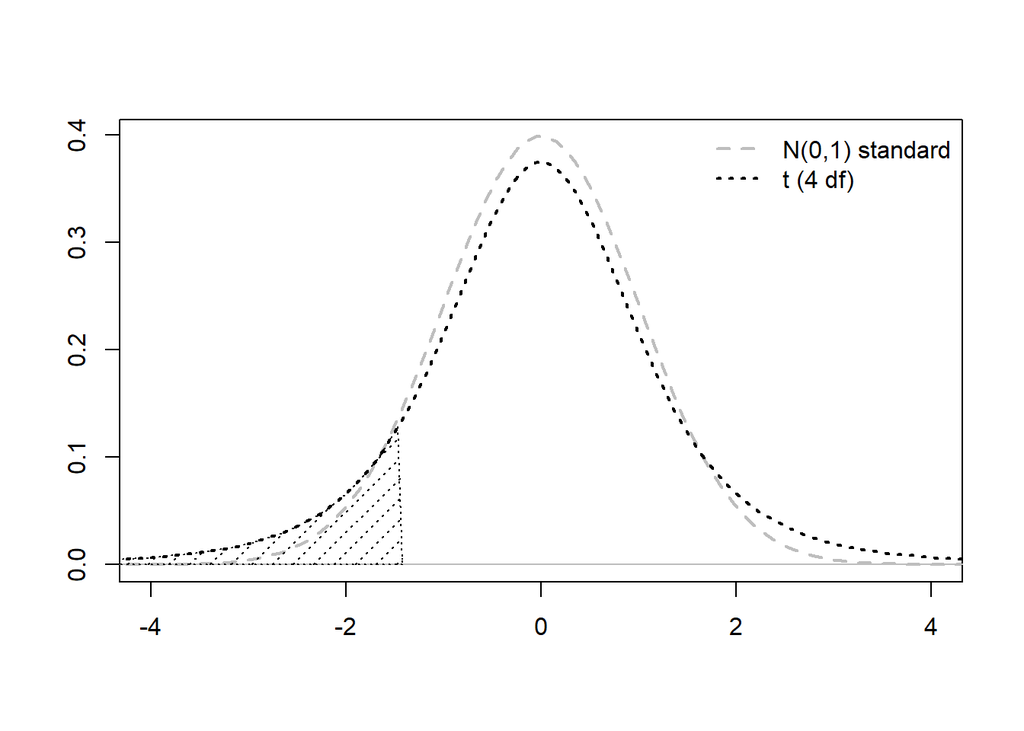

```r
#Distributia t cu v = 4, marcheaza probabilitatea. Densitatea N(0,1) este reprezentata grafic pentru comparatie, aceasta reprezinta versiunea standardizata a N(22, 1.5/√5)

xvals <- seq(-5,5,length=100)
fx.samp.t <- dt(xvals,df=4)
plot(xvals,dnorm(xvals),type="l",lty=2,lwd=2,col="gray",xlim=c(-4,4),
xlab="",ylab="")
abline(h=0,col="gray")
lines(xvals,fx.samp.t,lty=3,lwd=2)
polygon(cbind(c(t4,-5,xvals[xvals<=t4]),c(0,0,fx.samp.t[xvals<=t4])),
density=10,lty=3)
legend("topright",legend=c("N(0,1) standard","t (4 df)"),
col=c("gray","black"),lty=2:3,lwd=c(2,2),bty="n")
```

### 1.2 Distributia de esantionare a proportiei

**Distributia de esantionare a proportiei** masoara proportia de succes, adica sansa de aparitie a anumitor evenimente, impartind numarul de succese, adica sansele, la dimensiunea esantionului **n**. Astfel, proportia esantionului este definita ca p = x / n, unde x este numarul de succese intr-un esantion de marime n.

```r
#estimarea proportiei de interes
p.hat <- 80/118
p.hat
```

```
## [1] 0.6779661
```

```r
#aproximarea la distributia normala este valida, deoarece ambele valori sunt mai mari decat 5.
118*p.hat
```

```
## [1] 80
```

```r
118*(1-p.hat)
```

```
## [1] 38
```

```r
#estimarea erorii standard
p.se <- sqrt(p.hat * (1-p.hat) / 118)
p.se
```

```
## [1] 0.04301439
```

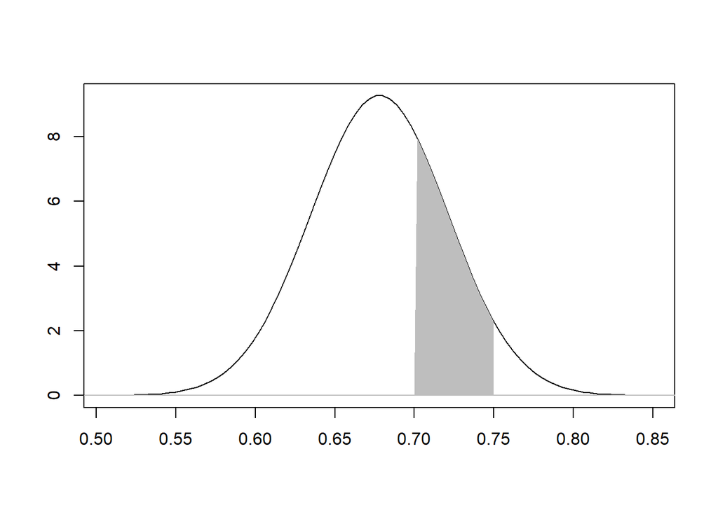

```r
#reprezentarea grafica a distributiei de esantionare:
pvals <- seq(p.hat-5*p.se,p.hat+5*p.se,length=100)
p.samp <- dnorm(pvals,mean=p.hat,sd=p.se)
plot(pvals,p.samp,type="l",xlab="",ylab="",
xlim=p.hat+c(-4,4)*p.se,ylim=c(0,max(p.samp)))
abline(h=0,col="gray")
pvals.sub <- pvals[pvals>=0.7 & pvals<=0.75]
p.samp.sub <- p.samp[pvals>=0.7 & pvals<=0.75]
polygon(cbind(c(0.7,pvals.sub,0.75),c(0,p.samp.sub,0)),
border=NA,col="gray")
```

```r
#calcularea probabilitatii de interes
pnorm(0.75,mean=p.hat,sd=p.se) - pnorm(0.7,mean=p.hat,sd=p.se)
```

```
## [1] 0.257238
```

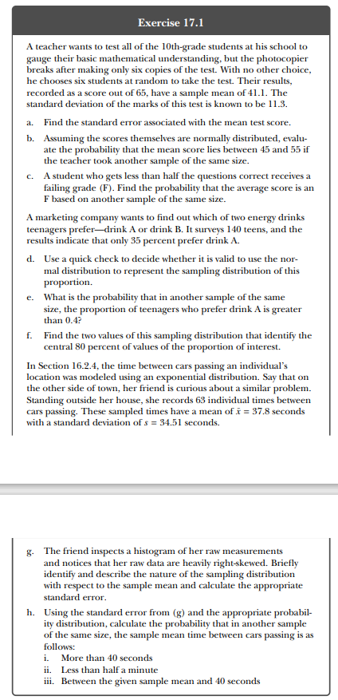

## Raspunsuri

```r
#Exercitiul 1

mean <- 41.1
sd <- 11.3
n <- 6

#a
se <- sd / sqrt(n)
se
```

```
## [1] 4.613206
```

```r
#b
pnorm(55, mean, se) - pnorm (45, mean, se)
```

```
## [1] 0.197651
```

```r
#c
pnorm(65/2, mean, se)
```

```
## [1] 0.03114587
```

```r
#Exericitul 2
n <- 140
p <- 0.35 #probabilitatea ca A sa fie ales

#d
p * n >= 5 & n * (1 - p) >= 5
```

```
## [1] TRUE
```

```r
#e
se <- sqrt(p * (1-p) / n )
1 - pnorm(0.4, p, se)
```

```
## [1] 0.1074235
```

```r
#f
upper <- qnorm(0.9, p , se)
lower <- qnorm(0.1, p, se)

#Exercitiul 3

n <- 63
xmean <- 37.8
s <- 34.51

#g
se <- s/sqrt(n)
df <- n - 1

#i
newx <- (40 - xmean) / se
1 - pt(newx, df)
```

```
## [1] 0.3073266
```

```r
#ii
newx <- (30 - xmean) / se
pt(newx, df)
```

```
## [1] 0.03884552
```

```r
#iii
newx <- (40 - xmean) / se
pt(newx, df) - 0.5
```

```
## [1] 0.1926734
```

## 2. Intervale de incredere

Un **interval de incredere** (IC) este un interval definit de o limita inferioara **l** si o limita superioara **u**, utilizata pentru a descrie valorile posibile ale unui parametru real corespunzator al populatiei in functie de esantionul observat. Prin urmare, interpretarea unui interval de incredere ne permite sa afirmam un „nivel de incredere” ca un adevarat parametru de interes se afla intre aceasta limita superioara si inferioara, adesea exprimat ca procent.

### 2.1 Un interval pentru medie

Un interval de incredere pentru medie ne ofera o gama de valori plauzibile pentru media populatiei. Daca un interval de incredere nu include o anumita valoare, putem spune ca nu este probabil ca respectiva valoare sa fie adevarata medie a populatiei.

Revenind la exemplul anterior legat de media zilnica a temperaturii maxime a lunii ianuarie pentru Dunedin, New Zeeland. Sa presupunem ca observatiile sunt distribuite in mod normal, dar nu se cunoaste adevarata medie µX (care este setata la 22) sau adevarata abatere standard (care este stabilita la 1,5).

```r
temp.sample <- rnorm(n=5,mean=22,sd=1.5)
temp.sample
```

```
## [1] 20.04412 22.87423 20.89876 24.34958 21.43546
```

```r
#calcularea mediei esantionului, a abaterii standard si a erorii standard corespunzatoare a mediei esantionului
temp.mean <- mean(temp.sample)
temp.mean
```

```
## [1] 21.92043
```

```r
temp.sd <- sd(temp.sample)
temp.sd
```

```
## [1] 1.703675
```

```r
temp.se <- temp.sd/sqrt(5)
temp.se
```

```
## [1] 0.7619065
```

```r
#Valoarea critica (pozitiva) se gaseste prin furnizarea unei probabilitatii de 1 − α/2 = 0,975 a functiei corespunzatoare.

1-0.05/2
```

```
## [1] 0.975
```

```r
critval <- qt(0.975, df = 4)
critval
```

```
## [1] 2.776445
```

```r
#aria centrala, simetrica, sub curba, trebuie sa fie 0.95. Se poate confirma acest lucru folosind pt.
pt(critval,4)-pt(-critval,4)
```

```
## [1] 0.95
```

```r
#gasirea intervalului de incredere de 95% pentru adevarata medie, rezultand l si respectiv u, astfel:
temp.mean-critval*temp.se
```

```
## [1] 19.80504
```

```r
temp.mean+critval*temp.se
```

```
## [1] 24.03582
```

```r
#un interval de incredere de 80% (α = 0,2) si un interval de incredere de 99% (α = 0,01) pentru aceeasi valoare data:

temp.mean+c(-1,1)*qt(p=0.9,df=4)*temp.se
```

```
## [1] 20.75227 23.08859
```

```r
temp.mean+c(-1,1)*qt(p=0.995,df=4)*temp.se
```

```
## [1] 18.41254 25.42832
```

### 2.2 Un interval pentru proportie

Revenind la exemplul anterior, in care 80 din 118 persoane intervievate au spus ca stiu cum vor vota la urmatoarele alegeri prezidentiale din SUA:

```r
p.hat <- 80/118
p.hat
```

```
## [1] 0.6779661
```

```r
p.se <- sqrt(p.hat*(1-p.hat)/118)
p.se
```

```
## [1] 0.04301439
```

```r
#pentru a construi un interval de incredere de 90 % (α = 0,1), valoarea critica adecvata din distributia de esantionare standardizata de interes este dupa cum urmeaza, implicand Pr(−1,644854 < Z < 1,644854) = 0,9 pentru Z ∼ N(0,1):

qnorm(0.95)
```

```
## [1] 1.644854
```

```r
#putem concluziona, in proportie de 90%, ca proportia reala de alegatori care stiu cum vor vota la urmatoarele alegeri se afla intre 0,61 si 0,75.

p.hat + c(-1,1) * qnorm(0.95)*p.se
```

```
## [1] 0.6072137 0.7487185
```

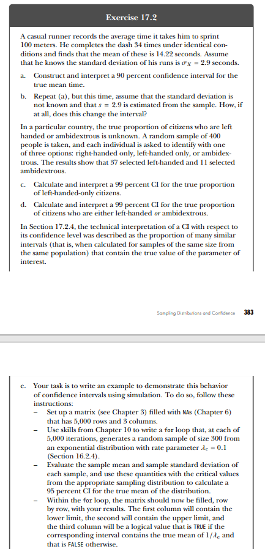

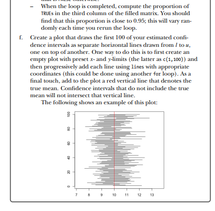

## Raspunsuri

```r
n=34
x.bar<-14.22
sigma<-2.9

#a. construirea si interpretarea unui interval de incredere de 90% pentru timpul mediu adevarat
alpha<-1-.9
x.bar+c(-1,1)*qnorm(1-alpha/2)*(sigma/sqrt(n))
```

```
## [1] 13.40194 15.03806
```

```r
#b.
s<-2.9
x.bar+c(-1,1)*qt(1-alpha/2,df=n-1)*(s/sqrt(n))
```

```
## [1] 13.37831 15.06169
```

```r
n<-400
#optiunea B = stangaci
p.b<-37/n
p.b
```

```
## [1] 0.0925
```

```r
#optiunea C = ambidextri
p.c<-11/n
p.c
```

```
## [1] 0.0275
```

```r
#optiunea A = dreptaci
p.a<-1-p.b-p.c
p.a
```

```
## [1] 0.88
```

```r
#c. calcularea unui IC de 99% pentru proportia reala de cetateni care sunt B

alpha<-1-0.99
p.b+(c(-1,1)*qnorm(1-alpha/2))*sqrt(p.b*(1-p.b)/n)
```

```
## [1] 0.05518519 0.12981481
```

```r
#d. 99% incredere in IC a proportiei realea cetatenilor stangaci sau ambidextri

(p.b + p.c)+ c(-1, 1) * qnorm(1 - alpha / 2) * (sqrt((p.b + p.c) * (1 - (p.b + p.c)) / n))
```

```
## [1] 0.07814773 0.16185227
```

```r
#e.

x.mat<-matrix(NA,5000,3)
n<-300
lambda<-0.1
mu<-1/lambda

for(i in 1: nrow(x.mat)) {
  sample <- rexp(n, lambda)
  limits <- mean(sample) + c(-1,1) * qt(1-0.05/2, df = n-1) * (sd(sample) / sqrt(n))
  x.mat[i, 1:2] <- limits
  x.mat[i, 3] <- mu >= limits[1]&mu<=limits[2]
}
mean(x.mat[,3])
```

```
## [1] 0.9442
```

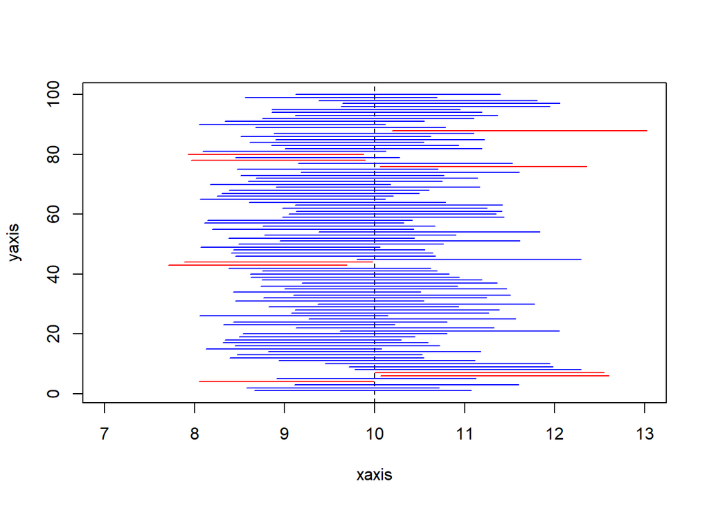

```
## integer(0)
```

```r
#reprezentarea grafica a primelor 100 intervale de incredere cu media la mijloc

xaxis<-seq(mu-3,mu+3,length=100)
yaxis<-1:100

plot(xaxis, yaxis, type = "n") + abline(v = 10, lty = 2) + for (i in 1:length(xaxis)) {
lines(c(x.mat[i, 1], x.mat[i, 2]), c(i, i), col = if (x.mat[i, 1] < 10 & x.mat[i, 2] > 10) {
                        "blue"
                  } else{
                        "red"
                  })



      }
```

## 3. Componentele unui test de ipoteza

Testarea ipotezei este o procedura statistica in care se alege intre o ipoteza nula si o ipoteza alternativa bazate pe informatiile dintr-un esantion.

### - Ipoteze

**Ipoteza nula**, notata H0, este afirmatia despre parametrul populatiei care se presupune ca este adevarata, cu exceptia cazului in care exista dovezi convingatoare care sa confirme contrariul.

**Ipoteza alternativa**, notata Ha, este o afirmatie despre parametrul populatiei care este in contradictie cu ipoteza nula si este acceptata ca adevarata numai daca exista dovezi convingatoare in favoarea acesteia.

### - Test Statistic

Odata formate ipotezele, sunt colectate datele din esantion si sunt calculate statistici in functie de parametrii detaliati in ipoteze. Testul statistic reprezinta statistica comparata cu standardul corespunzator a distributiei de esantionare pentru a obtine valoarea p.

### - p-value

Valoarea p este valoarea probabilitatii care este utilizata pentru a cuantifica cantitatea de dovezi, daca exista, impotriva ipotezei nule. Mai simplu spus, cu cat statistica testului este mai extrema, cu atat valoarea p este mai mica. Cu cât valoarea p este mai mica, cu atat este mai mare cantitatea de dovezi statistice impotriva adevarului presupus al lui H0.

### - Nivel de semnificatie

Pentru fiecare test de ipoteza, se presupune un nivel de semnificatie, notat α. Aceasta este folosit pentru a stabili rezultatul testului. Nivelul de semnificatie defineste o limita, in urma careia se decide daca exista suficiente dovezi pentru a vedea H0 ca incorect si a favoriza Ha in schimb.

- Daca valoarea p este mai mare sau egala cu α, atunci se accepta ipoteza nula in favoarea celei alternative.
- Daca valoarea p este mai mica decat α, atunci se respinge ipoteza nula si se accepta ipoteza alternativa.

## 4. Testarea mediilor

### 4.1 O singura medie

#### t-Test cu un esantion

t-Test pentru un esantion este un test de ipoteza statistica utilizat pentru a determina daca o medie necunoscuta a populatiei este diferita de o anumita valoare.

Un producator de snacks-uri este interesat de greutatea neta medie a continutului dintr-un pachet de 80 de grame. Un consumator suna si depune o plangere - de-a lungul timpului a cumparat si a cantarit exact continutul a 44 de pachete de 80 de grame alese aleatoriu din diferite magazine si a inregistrat greutatile astfel:

```r
 snacks <- c(87.7,80.01,77.28,78.76,81.52,74.2,80.71,79.5,77.87,81.94,80.7,
82.32,75.78,80.19,83.91,79.4,77.52,77.62,81.4,74.89,82.95,
73.59,77.92,77.18,79.83,81.23,79.28,78.44,79.01,80.47,76.23,
78.89,77.14,69.94,78.54,79.7,82.45,77.29,75.52,77.21,75.99,
81.94,80.41,77.7)

#Clientul sustine ca datele nu pot fi provenite dintr-o distributie cu media µ = 80, deci media adevărată greutatea trebuie să fie mai mică de 80.

#se definesc ipotezele astfel: H0: µ = 80 si Ha: µ < 80
#se calculeaza media si abaterea standard a esantionului

n <- length(snacks)
snack.mean <- mean(snacks)
snack.mean
```

```
## [1] 78.91068
```

```r
snack.sd <- sd(snacks)
snack.sd
```

```
## [1] 3.056023
```

```r
#se calculeaza testul statistic, primul pas fiind calcularea erorii standard a esantionului pentru datele din snacks

snack.se <- snack.sd/sqrt(n)
snack.se
```

```
## [1] 0.4607128
```

```r
#apoi se calculeaza T:

snack.T <- (snack.mean-80)/snack.se
snack.T
```

```
## [1] -2.364419
```

```r
#testul statistic este utilizat pentru a obtine p, asadar:
#deoarece p este mai mic decat α = 0,05, exista suficiente dovezi pentru a respinge ipoteza nula

pt(snack.T, df = n-1)
```

```
## [1] 0.01132175
```

```r
#rezultatul testului T cu un esantion poate fi gasit si cu functia t.test
t.test(x=snacks,mu=80,alternative="less")
```

```
##
##  One Sample t-test
##
## data:  snacks
## t = -2.3644, df = 43, p-value = 0.01132
## alternative hypothesis: true mean is less than 80
## 95 percent confidence interval:
##      -Inf 79.68517
## sample estimates:
## mean of x
##  78.91068
```

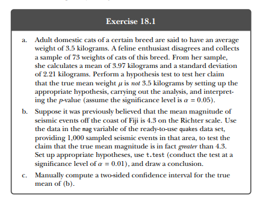

## Raspunsuri

```r
#a.

mu<-3.5

n<-73
x.bar<-3.97
x.sd<-2.21
#semnificatie = 0.05
#H0<- 3.35
#Ha != H0

#probabilitatea este mai mare decat alfa (valoarea semnificatiei). Asadar, nu avem motive sa credem ca ipoteza H0 nu este adevarata.

t<-(x.bar-mu)/(x.sd/sqrt(n))
p<-pt(-t,df=n-1)+(1-pt(t,df=n-1))

#Intervalul de incredere contine H0
IC<- x.bar+c(-1,1)*qt(0.975,n-1)*x.sd/sqrt(n)

#b.
#magnitudinea medie a evenimentelor seismice din Fiji
mu <- 4.3

# Ha > H0
alpha <- 0.01
remove(x.bar)

#valoare p este prea mica - dovada puternica - adevarata magnitudine e mai mare decat 4,3

t.test(quakes$mag,mu=mu,alternative="greater",conf.level=1-alpha)
```

```
##
##  One Sample t-test
##
## data:  quakes$mag
## t = 25.155, df = 999, p-value < 2.2e-16
## alternative hypothesis: true mean is greater than 4.3
## 99 percent confidence interval:
##  4.590722      Inf
## sample estimates:
## mean of x
##    4.6204
```

```r
#c.
#Intervalul de incredere nu contine media H0 pentru adevarata valoare a mediei
n<-length(quakes$mag)
n
```

```
## [1] 1000
```

```r
IC<-mean(quakes$mag)+ c(-1,1)*qt(1-0.01/2,n-1)* sd(quakes$mag)/sqrt(n)
IC
```

```
## [1] 4.587529 4.653271
```

### 4.2 Doua medii

Adesea, testarea mediei unui singur esantion nu este suficienta. In multe situatii, se doreste compararea directa a mediilor a doua grupuri distincte de masuratori. Modul in care doua grupuri de date relationeaza unul cu celalalt afecteaza forma specifica a erorii standard pentru diferenta dintre doua medii ale esantioanelor si deci statistica testului in sine.

#### Esantioane independente, cu dispersii diferite

Cel mai general caz este cel in care cele doua seturi de masuratori se bazeaza pe doua grupuri independente, separate (denumite si esantioane nepereche). Se calculeaza mediile esantionului si abaterile standard esantionate ale ambelor seturi de date, se definesc ipotezele de interes si apoi se calculeaza statistica testului.

Pentru un exemplu de esantioane independente, cu disperii diferite, revenim la exemplul cu pachetul de snacks-uri de 80 de grame. Dupa colectarea unui esantion de 44 de pachete (marime notata cu n1). Consumatorul nemultumit colecteaza n2 = 31 pachete de 80 de grame alese aleatoriu de la un producator rival de snacks-uri. Acest set de date se stocheaza in snacks2.

```r
snacks2 <- c(80.22,79.73,81.1,78.76,82.03,81.66,80.97,81.32,80.12,78.98,
79.21,81.48,79.86,81.06,77.96,80.73,80.34,80.01,81.82,79.3,
79.08,79.47,78.98,80.87,82.24,77.22,80.03,79.2,80.95,79.17,81)


#calcularea mediei si a abaterii standard pentru al doilea esantion

snack2.mean <- mean(snacks2)
snack2.mean
```

```
## [1] 80.1571
```

```r
snack2.sd <- sd(snacks2)
snack2.sd
```

```
## [1] 1.213695
```

```r
#adevarata media a noului esantion este notat cu µ2. Se construiesc ipotezele astfel:
#H0 : µ2 − µ1 = 0
#HA : µ2 − µ1 > 0

#efectuarea testului cu alternative="greater", snacks2 sunt cele furnizate lui x:

t.test(x=snacks2,y=snacks,alternative="greater",conf.level=0.9)
```

```
##
##  Welch Two Sample t-test
##
## data:  snacks2 and snacks
## t = 2.4455, df = 60.091, p-value = 0.008706
## alternative hypothesis: true difference in means is greater than 0
## 90 percent confidence interval:
##  0.5859714       Inf
## sample estimates:
## mean of x mean of y
##  80.15710  78.91068
```

```r
#se poate interpreta astfel: „90 % increzator ca adevarata diferenta intre greutatea medie neta dintre rival si producatorul original este undeva intre 0,395 si 2,098 grame.

(snack2.mean-snack.mean) + c(-1,1)*qt(0.95,df=60)*sqrt(snack.sd^2/44+snack2.sd^2/31)
```

```
## [1] 0.3949179 2.0979120
```

#### Esantioane independente, cu dispersii egale

Daca se poate presupune echivalenta variantelor, precizia testului este imbunatatita - se folosesc formule diferite pentru eroarea standard a diferentei si pentru calculul df asociat.

Sa presupunem, in mod rezonabil, ca scorurile IQ sunt distribuite in mod normal, iar IQ-ul mediu al populatiei este de 100. Ne intereseaza sa evaluam daca exista o diferenta intre media IQ-ului dintre barbati si femei, sugerand urmatoarele ipoteze: nmen = 12 si nwomen = 20:

- H0: µmen - µwomen = 0
- Ha: µmen - µwomen != 0

```r
men <- c(102,87,101,96,107,101,91,85,108,67,85,82)
women <- c(73,81,111,109,143,95,92,120,93,89,119,79,90,126,62,92,77,106,
105,111)
#se calculeaza media si abaterea standard a esantioanelor
mean(men)
```

```
## [1] 92.66667
```

```r
sd(men)
```

```
## [1] 12.0705
```

```r
mean(women)
```

```
## [1] 98.65
```

```r
sd(women)
```

```
## [1] 19.94802
```

```r
#raportul abaterilor standard:
sd(women)/sd(men)
```

```
## [1] 1.652626
```

```r
#Testul T

t.test(x=men,y=women,alternative="two.sided",conf.level=0.95,var.equal=TRUE)
```

```
##
##  Two Sample t-test
##
## data:  men and women
## t = -0.93758, df = 30, p-value = 0.3559
## alternative hypothesis: true difference in means is not equal to 0
## 95 percent confidence interval:
##  -19.016393   7.049727
## sample estimates:
## mean of x mean of y
##  92.66667  98.65000
```

#### Esantioane pereche

Datele pereche apar daca masuratorile care formeaza cele doua seturi de observatii sunt inregistrate pentru acelasi individ sau daca sunt legate intre ele intr-un mod important sau evident.

Se ia in considerare o companie interesata de eficacitatea unui medicament conceput pentru a reduce frecventa cardiaca in repaus in batai pe minut (bpm). Este masurata frecventa cardiaca de repaus a 16 indivizii.Indivizilor li se administreaza apoi un tratament si li se masoara din nou ritmul cardiac de repaus. Datele sunt furnizate in cei doi vectori rate.before si rate.after:

```r
rate.before <- c(52,66,89,87,89,72,66,65,49,62,70,52,75,63,65,61)
rate.after <- c(51,66,71,73,70,68,60,51,40,57,65,53,64,56,60,59)

#Testul T cu doua esantioane pereche ia in considerare diferenta dintre fiecare pereche de valori.

rate.d <- rate.after-rate.before
rate.d
```

```
##  [1]  -1   0 -18 -14 -19  -4  -6 -14  -9  -5  -5   1 -11  -7  -5  -2
```

```r
#este calculata media esantionului si abaterea standard a acestor diferente:
rate.dbar <- mean(rate.d)
rate.dbar
```

```
## [1] -7.4375
```

```r
rate.sd <- sd(rate.d)
rate.sd
```

```
## [1] 6.196437
```

```r
#vrem sa vedem cu cat se reduce ritmul cardiac, asa ca testul va avea urmatoarele ipoteze:
#H0 : µd = 0
#Ha : µd < 0

#oentru exemplele actuale de ipoteze, se poate gasi statistica testului si valoarea p cu rate.dbar si rate.sd
rate.T <- rate.dbar/(rate.sd/sqrt(16))
rate.T
```

```
## [1] -4.801146
```

```r
pt(rate.T, df = 15)
```

```
## [1] 0.000116681
```

```r
#aceste rezultate sugereaza dovezi pentru respingerea H0.
t.test(x=rate.after,y=rate.before,alternative="less",conf.level=0.95,
paired=TRUE)
```

```
##
##  Paired t-test
##
## data:  rate.after and rate.before
## t = -4.8011, df = 15, p-value = 0.0001167
## alternative hypothesis: true mean difference is less than 0
## 95 percent confidence interval:
##       -Inf -4.721833
## sample estimates:
## mean difference
##         -7.4375
```

```r
#putem spune ca suntem 95% increzatori ca adevarata diferenta medie a frecventei cardiace dupa administrarea tratamentului se afla undeva intre
rate.dbar-qt(0.975,df=15)*(rate.sd/sqrt(16))
```

```
## [1] -10.73935
```

```r
#si
rate.dbar+qt(0.975,df=15)*(rate.sd/sqrt(16))
```

```
## [1] -4.135652
```

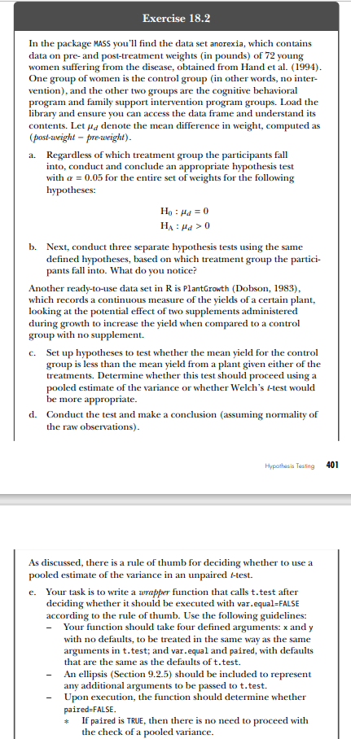

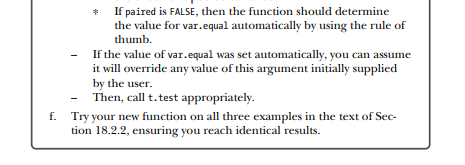